# SURVIVAL ANALYSIS IN R

BY : Kikonyogo Steven

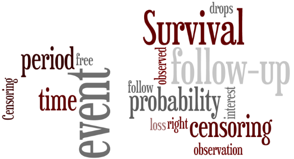

## WHAT IS SURVIVAL ANALYSIS ?

*Survival analysis* focuses on describing for a given individual or group of individuals, a defined point of event called *the failure* ( such as occurrence of a disease, cure from a disease, death, relapse after response to treatment…) that occurs after a period of time called *failure time* during which individuals are observed. It is usually expressed through the *survival probability* which is the probability that the event of interest has not occurred by a duration, t.

In short, survival data can be described as having the following three characteristics:

1. the dependent variable or response is the waiting time until the occurrence of a well-defined event,
2. observations can be censored, in the sense that for some units the event of interest has not occurred at the time the data are analyzed, and
3. there are predictors or explanatory variables whose effect on the waiting time we wish to assess or control.

### **Loading packages**

```r
if(!require(pacman)) install.packages("pacman")
```

```r
pacman::p_load(
              gt,
              rio,
              here,
              dplyr,
              ggplot2,
              magrittr,
              janitor,
              survival,
              flextable
              )
```

### **Importing data into R**

```r
DF <- rio::import(here("C:/Users/steven/Desktop/PROJECTS/colon.csv"))
  DF %>%
  select(
         time,
         age) %>%
  mutate(
         follow_up=time/365) %>%
  summary()
```

```
##       time             age          follow_up
##  Min.   :   8.0   Min.   :18.00   Min.   :0.02192
##  1st Qu.: 379.8   1st Qu.:53.00   1st Qu.:1.04041
##  Median :1556.0   Median :61.00   Median :4.26301
##  Mean   :1410.4   Mean   :59.81   Mean   :3.86399
##  3rd Qu.:2289.8   3rd Qu.:69.00   3rd Qu.:6.27329
##  Max.   :3329.0   Max.   :85.00   Max.   :9.12055
```

```r
 DF1 <- subset(DF,rx >= 2)
```

### **Data Exploration**

```r
colon <- DF1 %>%
     select(
         time,
         status,
         rx,
         age,
         sex) %>%
    mutate(
          follow_up=time/365,
          event = ifelse(status==1, "death", "censored"),
          trt_ype  = ifelse(rx==2, "amisole", "amisole+5-FU"),
          gender = ifelse(sex == 1, "male", "female"),
          age_cat = case_when(
          age < 35 ~ "0 - 34",
          age >= 35 & age < 65 ~ "35 - 64",
          age >= 65 ~ "65+")
          )

any(is.na(colon))
```

```
## [1] FALSE
```

```r
str(colon)
```

```
## 'data.frame':    594 obs. of  10 variables:
##  $ time     : int  8 9 20 23 36 40 43 45 45 49 ...
##  $ status   : int  1 1 1 0 1 1 1 1 0 1 ...
##  $ rx       : int  3 3 2 3 2 3 2 2 3 3 ...
##  $ age      : int  32 55 66 52 60 58 79 41 73 61 ...
##  $ sex      : int  0 1 1 0 0 0 1 1 1 0 ...
##  $ follow_up: num  0.0219 0.0247 0.0548 0.063 0.0986 ...
##  $ event    : chr  "death" "death" "death" "censored" ...
##  $ trt_ype  : chr  "amisole+5-FU" "amisole+5-FU" "amisole" "amisole+5-FU" ...
##  $ gender   : chr  "female" "male" "male" "female" ...
##  $ age_cat  : chr  "0 - 34" "35 - 64" "65+" "35 - 64" ...
```

```r
head(colon,10)
```

```
##    time status rx age sex  follow_up    event      trt_ype gender age_cat
## 1     8      1  3  32   0 0.02191781    death amisole+5-FU female  0 - 34
## 2     9      1  3  55   1 0.02465753    death amisole+5-FU   male 35 - 64
## 4    20      1  2  66   1 0.05479452    death      amisole   male     65+
## 5    23      0  3  52   0 0.06301370 censored amisole+5-FU female 35 - 64
## 9    36      1  2  60   0 0.09863014    death      amisole female 35 - 64
## 11   40      1  3  58   0 0.10958904    death amisole+5-FU female 35 - 64
## 12   43      1  2  79   1 0.11780822    death      amisole   male     65+
## 13   45      1  2  41   1 0.12328767    death      amisole   male 35 - 64
## 14   45      0  3  73   1 0.12328767 censored amisole+5-FU   male     65+
## 15   49      1  3  61   0 0.13424658    death amisole+5-FU female 35 - 64
```

```r
tabyl(colon$gender)
```

```
##  colon$gender   n   percent
##        female 298 0.5016835
##          male 296 0.4983165
```

```r
tabyl(colon$trt_ype)
```

```
##  colon$trt_ype   n  percent
##        amisole 305 0.513468
##   amisole+5-FU 289 0.486532
```

```r
tabyl(colon$age_cat)
```

```
##  colon$age_cat   n    percent
##         0 - 34  21 0.03535354
##        35 - 64 339 0.57070707
##            65+ 234 0.39393939
```

```r
tabyl(colon$event)
```

```
##  colon$event   n  percent
##     censored 309 0.520202
##        death 285 0.479798
```

```r
colon %>%
  tabyl(gender, age_cat) %>%
  adorn_totals(where = "both") %>%
  adorn_percentages() %>%
  adorn_pct_formatting() %>%
  adorn_ns(position = "front") %>%
  gt()
```

| gender | 0 - 34 | 35 - 64 | 65+ | Total |
| --- | --- | --- | --- | --- |
| female | 12 (4.0%) | 168 (56.4%) | 118 (39.6%) | 298 (100.0%) |
| male | 9 (3.0%) | 171 (57.8%) | 116 (39.2%) | 296 (100.0%) |
| Total | 21 (3.5%) | 339 (57.1%) | 234 (39.4%) | 594 (100.0%) |

```r
colon %>%
  tabyl(gender, event) %>%
  adorn_totals(where = "both") %>%
  adorn_percentages() %>%
  adorn_pct_formatting() %>%
  adorn_ns(position = "front") %>%
  flextable()
```

| gender | censored | death | Total |
| --- | --- | --- | --- |
| female | 149 (50.0%) | 149 (50.0%) | 298 (100.0%) |
| male | 160 (54.1%) | 136 (45.9%) | 296 (100.0%) |
| Total | 309 (52.0%) | 285 (48.0%) | 594 (100.0%) |

```r
colon %>%
  tabyl(age_cat, event) %>%
  adorn_totals(where = "both") %>%
  adorn_percentages() %>%
  adorn_pct_formatting() %>%
  adorn_ns(position = "front") %>%
  gt()
```

| age_cat | censored | death | Total |
| --- | --- | --- | --- |
| 0 - 34 | 9 (42.9%) | 12 (57.1%) | 21 (100.0%) |
| 35 - 64 | 174 (51.3%) | 165 (48.7%) | 339 (100.0%) |
| 65+ | 126 (53.8%) | 108 (46.2%) | 234 (100.0%) |
| Total | 309 (52.0%) | 285 (48.0%) | 594 (100.0%) |

```r
colon %>%
  tabyl(trt_ype, event) %>%
  adorn_totals(where = "both") %>%
  adorn_percentages() %>%
  adorn_pct_formatting() %>%
  adorn_ns(position = "front") %>%
  flextable()
```

| trt_ype | censored | death | Total |
| --- | --- | --- | --- |
| amisole | 133 (43.6%) | 172 (56.4%) | 305 (100.0%) |
| amisole+5-FU | 176 (60.9%) | 113 (39.1%) | 289 (100.0%) |
| Total | 309 (52.0%) | 285 (48.0%) | 594 (100.0%) |

*Of the 888 patients, 594 were randomly allocated to the two treatments and of these, 298 were females(50.2%) and 296 males(49.8%).*

*305(51.3%) received old treatment while 289(48.7%) received new treatment. The minimum age was 18yrs and maximum was 85yrs.*